# Homework 4

Tianhao Jiang

The purpose of this homework is to get used to plotting and examining subsets of data. In the next lab we will have 25 million data points. And big instruments produce data at even more fantastic rates—our telescope in western Australia produces a billion data values per second, and we're hoping to upgrade it to produce at least an order of magnitude more.

You don't want to plot millions to billions of points on a plot, it will look like a blob and take forever. So we need to practice looking at subsets of the data.

I'll be using python code for examples today, but explain in words so they can be replicated in MatLab

```python
# Import Libraries
%matplotlib inline
import numpy as np
import matplotlib
import matplotlib.pyplot as plt
import scipy
from scipy import stats
from matplotlib.colors import LogNorm

plt.rcParams["figure.figsize"] = (15,10)
```

## Problem 0: some fake data to mess with

So let's start by making some fake background data.

First, let's make a time axis that goes from 0 to 100 π in 1e5 steps

t = np.linspace(0,np.pi*100,np.int(1e5))

Then an offset sinusoid

N = 10+np.sin(t)

Then some random background data whose mean and variance depend on N

bkgd = stats.norm.rvs(size=np.int(1e5))*np.sqrt(N)+N

Now this is small enough at only 100,000 points that you can plot it, but it is messy and not very informative.

```python
t = np.linspace(0,np.pi*100,np.int(1e5))
N = 10+np.sin(t)
bkgd = stats.norm.rvs(size=np.int(1e5))*np.sqrt(N)+N
```

## Problem 1: subsets of data

The idea here is to plot small portions of the data. In python this is often called array slicing, but in other languages it has no special terminology. Your goal is to figure out how to make the following plots:

**1a) Make a scatter plot (not a line plot) of the first 1000 data points.**

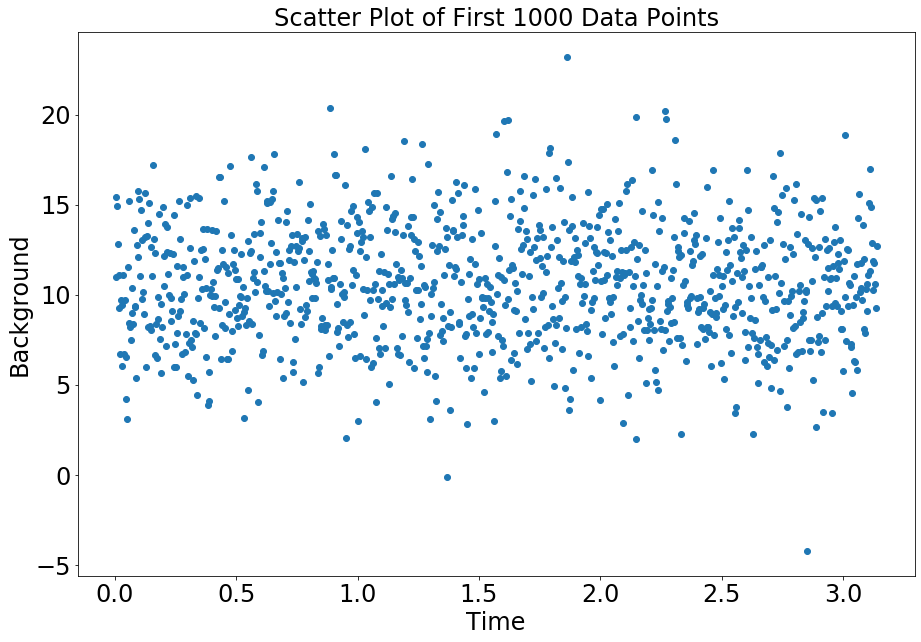

```python
fig, ax = plt.subplots(1, 1)
plt.tick_params(labelsize = 24)
ax.plot(t[1:1000],bkgd[1:1000],'o')
plt.xlabel("Time", fontsize = 24)
plt.ylabel("Background", fontsize = 24)
plt.title("Scatter Plot of First 1000 Data Points", fontsize = 24)
plt.show()
```

**1b) Generalize your code so you can make a plot of any X contiguous points (e.g. 2000 points starting at point 500), and produce an example plot of a set of data somethere in the middle of your array.**

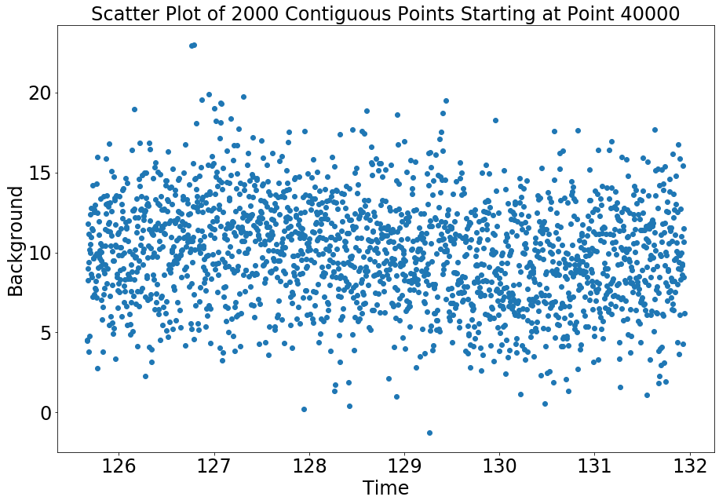

```python
num_points = 2000
start = 40000

data_range = range(start, start+num_points-1)
fig, ax = plt.subplots(1, 1)
plt.tick_params(labelsize = 24)
ax.plot(t[data_range],bkgd[data_range],'o')
plt.xlabel("Time", fontsize = 24)
plt.ylabel("Background", fontsize = 24)
plt.title("Scatter Plot of %d Contiguous Points Starting at Point %d" % (num_points, start), fontsize = 24)
plt.show()
```

**1c) Sometimes you want to sample the data, such as plotting every 100th point. Make a plot of the full data range, but only every 100th point.**

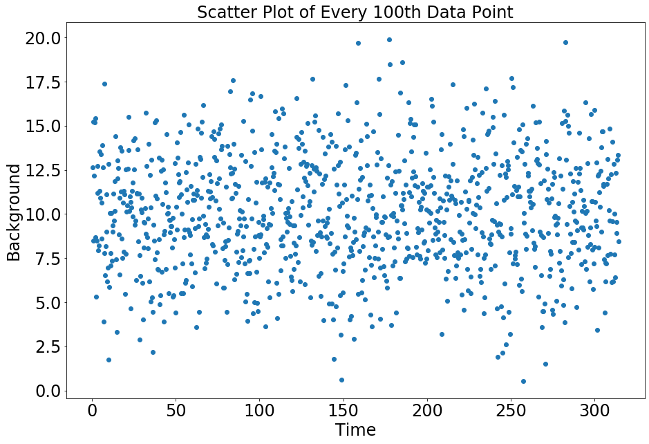

```python
step = 100
index = np.array([0]*int(len(t)/step))
for i in range(0,len(index)):
    index[i] = ((i+1)*step-1)


fig, ax = plt.subplots(1, 1)
plt.tick_params(labelsize = 24)
ax.plot(t[index],bkgd[index],'o')
plt.xlabel("Time", fontsize = 24)
plt.ylabel("Background", fontsize = 24)
plt.title("Scatter Plot of Every %dth Data Point" % step, fontsize = 24)
plt.show()
```

## Problem 2: density

Now you can make a scatter plot of just a 100,000 points, so you might try it to see what it looks like. But particularly in the central areas the points all overlap into just a blob, and this just gets worse as the number of points goes up. What is better is to plot the density of the points. There are several ways of doing this, but a 2D histogram plot is the easiest (plt.hist2d() in python and histogram2() in MatLab).

**2a) Make a 2d histogram plot. Read about options, and play with binsize so it is useful (too large a bin and everything washes out, too small and the sample noise dominates). Make sure you use a colorbar.**

I chose a bin size of 200 so that each period of the data correspond to a width of 4 bins.

**2b) Clearly explain what is being plotted in your plot (e.g. what does each color mean?)**

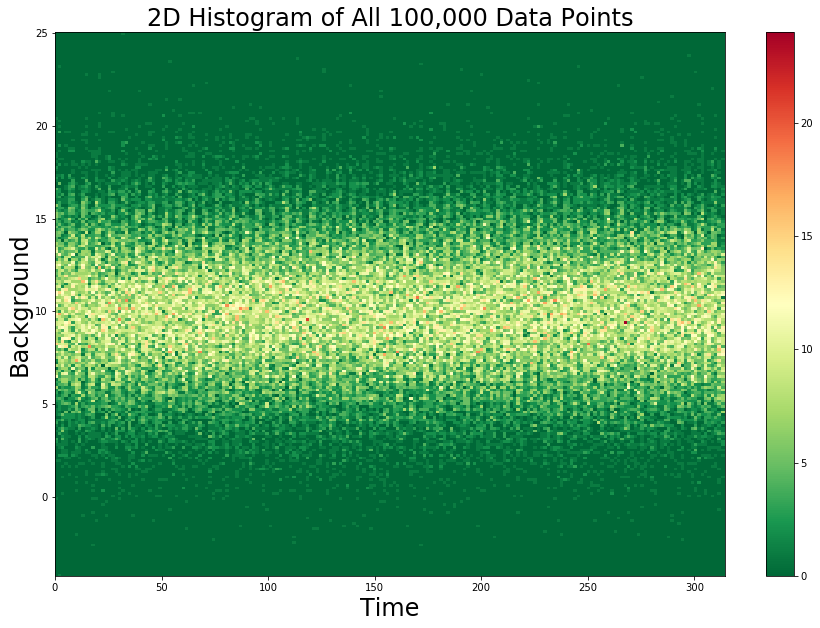

```python
plt.rcParams["figure.figsize"] = (15,10)
#plt.hist2d(t, bkgd, bins=100, norm=LogNorm())
plt.hist2d(t, bkgd, bins=200,cmap = "RdYlGn_r")
plt.colorbar()
plt.xlabel("Time", fontsize = 24)
plt.ylabel("Background", fontsize = 24)
plt.title("2D Histogram of All 100,000 Data Points", fontsize = 24)
plt.show()
```

The graph above plots a 2D histogram of the whole data set with 200*200 bins. The approximate number of data points included in each bin can be told by comparing the bin's color to the color bar. For example, by looking at the color bar, we can tell that green, yellow, and red bins correspond to approximately 0-8, 8-16, and 16-24 counts, respectively.

## Problem 3: folding

Now if you have a periodic signal, it is possible to fold the data stream at that period to make the pattern clearer.

**3a) Make an new time variable that folds at a period of 2π (the modulo operator is your friend, variably expressed *as mod(), %, or rem()). Then make a scatter plot of all your data, but now folded. (Reminder, for more data you'd never actually want to plot all the points.)**

```python
t_width = 2*np.pi
t_folded = np.mod(t, t_width) # calculate t1 which is t folded at a period of 2pi
```

**3b) Make a 2D histogram plot of your folded data.**

Optional, but very fun and useful:

**3c) You can use 2D histograms or digitize functions, plus some math, to calculate the average as a function of the folded variable. You can then overplot this on 3b to show the average as a function of folded time.**

Mean values are plotted as black dashed line.

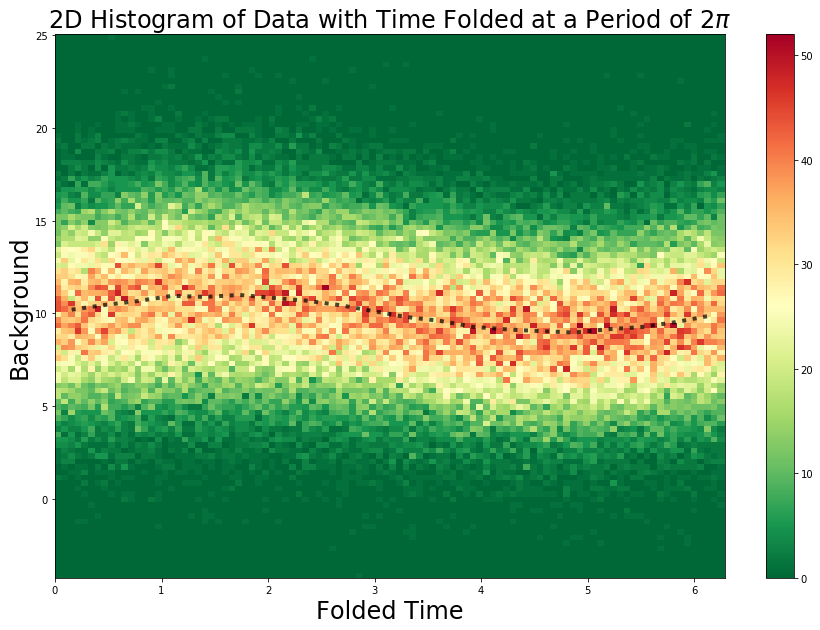

```python
# Calculate means
n = 20
t2 = np.linspace(0, t_width, n+1)
means = np.zeros(n)
for i in range(0,n):
    points = bkgd[(t_folded >= t2[i]) & (t_folded < t2[i+1])]
    means[i] = np.sum(points) / len(points)
t2 = t2[0:n] + (t2[1]-t2[0])/2

# Make plot
plt.rcParams["figure.figsize"] = (15,10)
#[h, xedges, yedges, image]=plt.hist2d(t_folded, bkgd, bins=10,cmap = "RdYlGn_r")
plt.hist2d(t_folded, bkgd, bins=100,cmap = "RdYlGn_r")
line, = plt.plot(t2,means,':k',linewidth = 4,alpha = 0.7)
plt.colorbar()
plt.xlabel("Folded Time", fontsize = 24)
plt.ylabel("Background", fontsize = 24)
plt.title("2D Histogram of Data with Time Folded at a Period of 2$\pi$", fontsize = 24)
plt.show()
```